# Prosper Loans

## Preliminary Wrangling

```python
# import all packages and set plots to be embedded inline
import numpy as np
import pandas as pd
import matplotlib.pyplot as plt
import seaborn as sb

%matplotlib inline

# suppress warnings from final output
import warnings
warnings.simplefilter("ignore")
```

```python
#Read in CSV and create a copy
df1 = pd.read_csv("prosperLoanData.csv")
df = df1.copy()
```

```python
#Call .info() to looks at name of columns and number of rows, datatypes and if there are missing values
df.info()
```

```
<class 'pandas.core.frame.DataFrame'>
RangeIndex: 113937 entries, 0 to 113936
Data columns (total 81 columns):
ListingKey                             113937 non-null object
ListingNumber                          113937 non-null int64
ListingCreationDate                    113937 non-null object
CreditGrade                            28953 non-null object
Term                                   113937 non-null int64
LoanStatus                             113937 non-null object
ClosedDate                             55089 non-null object
BorrowerAPR                            113912 non-null float64
BorrowerRate                           113937 non-null float64
LenderYield                            113937 non-null float64
EstimatedEffectiveYield                84853 non-null float64
EstimatedLoss                          84853 non-null float64
EstimatedReturn                        84853 non-null float64
ProsperRating (numeric)                84853 non-null float64
ProsperRating (Alpha)                  84853 non-null object
ProsperScore                           84853 non-null float64
ListingCategory (numeric)              113937 non-null int64
BorrowerState                          108422 non-null object
Occupation                             110349 non-null object
EmploymentStatus                       111682 non-null object
EmploymentStatusDuration               106312 non-null float64
IsBorrowerHomeowner                    113937 non-null bool
CurrentlyInGroup                       113937 non-null bool
GroupKey                               13341 non-null object
DateCreditPulled                       113937 non-null object
CreditScoreRangeLower                  113346 non-null float64
CreditScoreRangeUpper                  113346 non-null float64
FirstRecordedCreditLine                113240 non-null object
CurrentCreditLines                     106333 non-null float64
OpenCreditLines                        106333 non-null float64
TotalCreditLinespast7years             113240 non-null float64
OpenRevolvingAccounts                  113937 non-null int64
OpenRevolvingMonthlyPayment            113937 non-null float64
InquiriesLast6Months                   113240 non-null float64
TotalInquiries                         112778 non-null float64
CurrentDelinquencies                   113240 non-null float64
AmountDelinquent                       106315 non-null float64
```

[output cut: 31 more lines]

```
LP_CustomerPayments                    113937 non-null float64
LP_CustomerPrincipalPayments           113937 non-null float64
LP_InterestandFees                     113937 non-null float64
LP_ServiceFees                         113937 non-null float64
LP_CollectionFees                      113937 non-null float64
LP_GrossPrincipalLoss                  113937 non-null float64
LP_NetPrincipalLoss                    113937 non-null float64
LP_NonPrincipalRecoverypayments        113937 non-null float64
PercentFunded                          113937 non-null float64
Recommendations                        113937 non-null int64
InvestmentFromFriendsCount             113937 non-null int64
InvestmentFromFriendsAmount            113937 non-null float64
Investors                              113937 non-null int64
dtypes: bool(3), float64(50), int64(11), object(17)
memory usage: 68.1+ MB
```

```python
#get descriptive statistics for numeric columns
df.describe()
```

|  | ListingNumber | Term | BorrowerAPR | BorrowerRate | LenderYield | EstimatedEffectiveYield | EstimatedLoss | EstimatedReturn | ProsperRating (numeric) | ProsperScore | ... | LP_ServiceFees | LP_CollectionFees | LP_GrossPrincipalLoss | LP_NetPrincipalLoss | LP_NonPrincipalRecoverypayments | PercentFunded | Recommendations | InvestmentFromFriendsCount | InvestmentFromFriendsAmount | Investors |
| --- | --- | --- | --- | --- | --- | --- | --- | --- | --- | --- | --- | --- | --- | --- | --- | --- | --- | --- | --- | --- | --- |
| count | 1.139370e+05 | 113937.000000 | 113912.000000 | 113937.000000 | 113937.000000 | 84853.000000 | 84853.000000 | 84853.000000 | 84853.000000 | 84853.000000 | ... | 113937.000000 | 113937.000000 | 113937.000000 | 113937.000000 | 113937.000000 | 113937.000000 | 113937.000000 | 113937.000000 | 113937.000000 | 113937.000000 |
| mean | 6.278857e+05 | 40.830248 | 0.218828 | 0.192764 | 0.182701 | 0.168661 | 0.080306 | 0.096068 | 4.072243 | 5.950067 | ... | -54.725641 | -14.242698 | 700.446342 | 681.420499 | 25.142686 | 0.998584 | 0.048027 | 0.023460 | 16.550751 | 80.475228 |
| std | 3.280762e+05 | 10.436212 | 0.080364 | 0.074818 | 0.074516 | 0.068467 | 0.046764 | 0.030403 | 1.673227 | 2.376501 | ... | 60.675425 | 109.232758 | 2388.513831 | 2357.167068 | 275.657937 | 0.017919 | 0.332353 | 0.232412 | 294.545422 | 103.239020 |
| min | 4.000000e+00 | 12.000000 | 0.006530 | 0.000000 | -0.010000 | -0.182700 | 0.004900 | -0.182700 | 1.000000 | 1.000000 | ... | -664.870000 | -9274.750000 | -94.200000 | -954.550000 | 0.000000 | 0.700000 | 0.000000 | 0.000000 | 0.000000 | 1.000000 |
| 25% | 4.009190e+05 | 36.000000 | 0.156290 | 0.134000 | 0.124200 | 0.115670 | 0.042400 | 0.074080 | 3.000000 | 4.000000 | ... | -73.180000 | 0.000000 | 0.000000 | 0.000000 | 0.000000 | 1.000000 | 0.000000 | 0.000000 | 0.000000 | 2.000000 |
| 50% | 6.005540e+05 | 36.000000 | 0.209760 | 0.184000 | 0.173000 | 0.161500 | 0.072400 | 0.091700 | 4.000000 | 6.000000 | ... | -34.440000 | 0.000000 | 0.000000 | 0.000000 | 0.000000 | 1.000000 | 0.000000 | 0.000000 | 0.000000 | 44.000000 |
| 75% | 8.926340e+05 | 36.000000 | 0.283810 | 0.250000 | 0.240000 | 0.224300 | 0.112000 | 0.116600 | 5.000000 | 8.000000 | ... | -13.920000 | 0.000000 | 0.000000 | 0.000000 | 0.000000 | 1.000000 | 0.000000 | 0.000000 | 0.000000 | 115.000000 |
| max | 1.255725e+06 | 60.000000 | 0.512290 | 0.497500 | 0.492500 | 0.319900 | 0.366000 | 0.283700 | 7.000000 | 11.000000 | ... | 32.060000 | 0.000000 | 25000.000000 | 25000.000000 | 21117.900000 | 1.012500 | 39.000000 | 33.000000 | 25000.000000 | 1189.000000 |

8 rows × 61 columns

```python
#call .head() to look at data
df.head(5)
```

|  | ListingKey | ListingNumber | ListingCreationDate | CreditGrade | Term | LoanStatus | ClosedDate | BorrowerAPR | BorrowerRate | LenderYield | ... | LP_ServiceFees | LP_CollectionFees | LP_GrossPrincipalLoss | LP_NetPrincipalLoss | LP_NonPrincipalRecoverypayments | PercentFunded | Recommendations | InvestmentFromFriendsCount | InvestmentFromFriendsAmount | Investors |
| --- | --- | --- | --- | --- | --- | --- | --- | --- | --- | --- | --- | --- | --- | --- | --- | --- | --- | --- | --- | --- | --- |
| 0 | 1021339766868145413AB3B | 193129 | 2007-08-26 19:09:29.263000000 | C | 36 | Completed | 2009-08-14 00:00:00 | 0.16516 | 0.1580 | 0.1380 | ... | -133.18 | 0.0 | 0.0 | 0.0 | 0.0 | 1.0 | 0 | 0 | 0.0 | 258 |
| 1 | 10273602499503308B223C1 | 1209647 | 2014-02-27 08:28:07.900000000 | NaN | 36 | Current | NaN | 0.12016 | 0.0920 | 0.0820 | ... | 0.00 | 0.0 | 0.0 | 0.0 | 0.0 | 1.0 | 0 | 0 | 0.0 | 1 |
| 2 | 0EE9337825851032864889A | 81716 | 2007-01-05 15:00:47.090000000 | HR | 36 | Completed | 2009-12-17 00:00:00 | 0.28269 | 0.2750 | 0.2400 | ... | -24.20 | 0.0 | 0.0 | 0.0 | 0.0 | 1.0 | 0 | 0 | 0.0 | 41 |
| 3 | 0EF5356002482715299901A | 658116 | 2012-10-22 11:02:35.010000000 | NaN | 36 | Current | NaN | 0.12528 | 0.0974 | 0.0874 | ... | -108.01 | 0.0 | 0.0 | 0.0 | 0.0 | 1.0 | 0 | 0 | 0.0 | 158 |
| 4 | 0F023589499656230C5E3E2 | 909464 | 2013-09-14 18:38:39.097000000 | NaN | 36 | Current | NaN | 0.24614 | 0.2085 | 0.1985 | ... | -60.27 | 0.0 | 0.0 | 0.0 | 0.0 | 1.0 | 0 | 0 | 0.0 | 20 |

5 rows × 81 columns

```python
#create dataframes for columns we are curious in exploring, remove rows with null values
df_Deliquencies = df[["BorrowerAPR",'CurrentDelinquencies']]
df_Deliquencies.dropna(inplace=True)

df_ProsperRating = df[["BorrowerAPR",'ProsperRating (numeric)']]
df_ProsperRating.dropna(inplace=True)

df_EstimatedReturn = df[["BorrowerAPR",'EstimatedReturn']]
df_EstimatedReturn.dropna(inplace=True)

df_Credit = df[["CreditScoreRangeUpper",'BorrowerAPR']]
df_Credit.dropna(inplace=True)
```

```python
#check to see if it worked
df_ProsperRating.head(5)
```

|  | BorrowerAPR | ProsperRating (numeric) |
| --- | --- | --- |
| 1 | 0.12016 | 6.0 |
| 3 | 0.12528 | 6.0 |
| 4 | 0.24614 | 3.0 |
| 5 | 0.15425 | 5.0 |
| 6 | 0.31032 | 2.0 |

### What is/are the main feature(s) of interest in your dataset?

> The main columns I want to focus on are Borrower APR which is the amount interest on the loan.

### What features in the dataset do you think will help support your investigation into your feature(s) of interest?

> Other Features I want to explore are prosper rating, estimated return and Credit Score Upper Limit. For these I want to look at their relationship with Borrower APR

## Univariate Exploration

In this section I will plot and explore the distributions of Borrower APR, Prosper Rating and Credit score Range upper

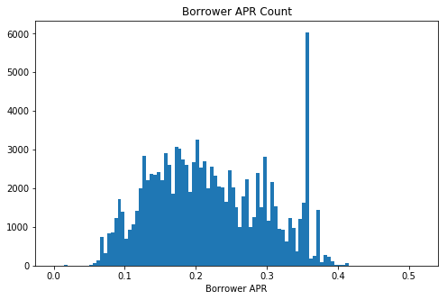

```python
#plot distribution of Borrower APR

binsize = .005
bins = np.arange(0, df['BorrowerAPR'].max()+binsize, binsize)

plt.figure(figsize=[8, 5])
plt.hist(data = df, x = 'BorrowerAPR', bins = bins,range=(0,1) )
plt.title("Borrower APR Count")
plt.xlabel('Borrower APR')
plt.show()
```

```python
#looks at value counts for Borrower APR, note most common value
df.BorrowerAPR.value_counts()
```

```
0.35797    3672
0.35643    1644
0.37453    1260
0.30532     902
0.29510     747
0.35356     721
0.29776     707
0.15833     652
0.24246     605
0.24758     601
0.12528     559
0.17359     549
0.15324     547
0.27462     534
0.27285     506
0.13799     489
0.15713     482
0.12691     456
0.25781     444
0.20735     433
0.26528     430
0.19501     425
0.20462     420
0.23318     416
0.15629     412
0.11296     409
0.34621     406
0.30564     399
0.20200     395
0.29537     391
           ...
0.12251       1
0.01875       1
0.26122       1
0.21403       1
0.18292       1
0.25104       1
0.18294       1
0.34986       1
0.08732       1
0.23361       1
0.08979       1
0.16587       1
0.29130       1
0.15145       1
0.27174       1
0.14609       1
0.23969       1
0.11315       1
0.18494       1
0.09348       1
0.21535       1
0.27000       1
0.13951       1
0.08706       1
0.23014       1
0.22825       1
0.22955       1
0.24844       1
0.30775       1
0.11833       1
Name: BorrowerAPR, Length: 6677, dtype: int64
```

The most common Borrower APR is .35797 and is followed by the very close APR of .35643. These two APRs account are on over 5000 different loans. Next I am going compare the counts of different prosper rating grades in the dataset.

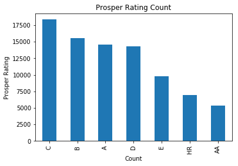

```python
#create bar chart of values for Prosper Rating

df['ProsperRating (Alpha)'].value_counts().plot(kind='bar')
plt.title('Prosper Rating Count')
plt.xlabel('Count')
plt.ylabel('Prosper Rating')
plt.figsize=(12,12)
```

```python
#look at value counts for Prosper Ratings
df['ProsperRating (Alpha)'].value_counts()
```

```
C     18345
B     15581
A     14551
D     14274
E      9795
HR     6935
AA     5372
Name: ProsperRating (Alpha), dtype: int64
```

the most common prosper rating grades are C with over 18,000 loans falling into that category, this would be the equivalent of prosper value 4 for numeric. The next most common grades are in order are: B, A, D, E, HR, and AA. Next I am going to explore the distrbution of Credit Range Scores.

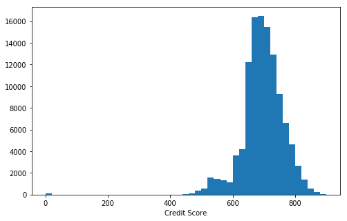

```python
#creeate distribution of Credit score upper ranges

binsize = 20
bins = np.arange(0, df['CreditScoreRangeUpper'].max()+binsize, binsize)

plt.figure(figsize=[8, 5])
plt.hist(data = df, x = 'CreditScoreRangeUpper', bins = bins,range=(0,1) )
plt.xlabel("Credit Score")
plt.show()
```

## Bivariate Exploration

```python
#create list of numeric values we want to explore
numeric_vars = ['BorrowerAPR', 'CreditScoreRangeUpper', 'ProsperRating (numeric)', 'DebtToIncomeRatio','CurrentDelinquencies','EstimatedReturn']
```

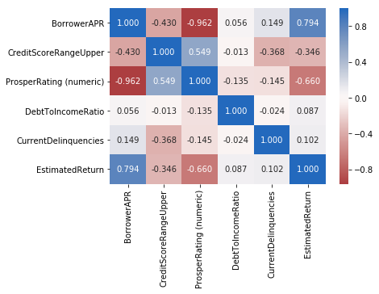

```python
#create heatmap of correlations of between numeric columns
sb.heatmap(df[numeric_vars].corr(), annot = True, fmt = '.3f',
           cmap = 'vlag_r', center = 0)
```

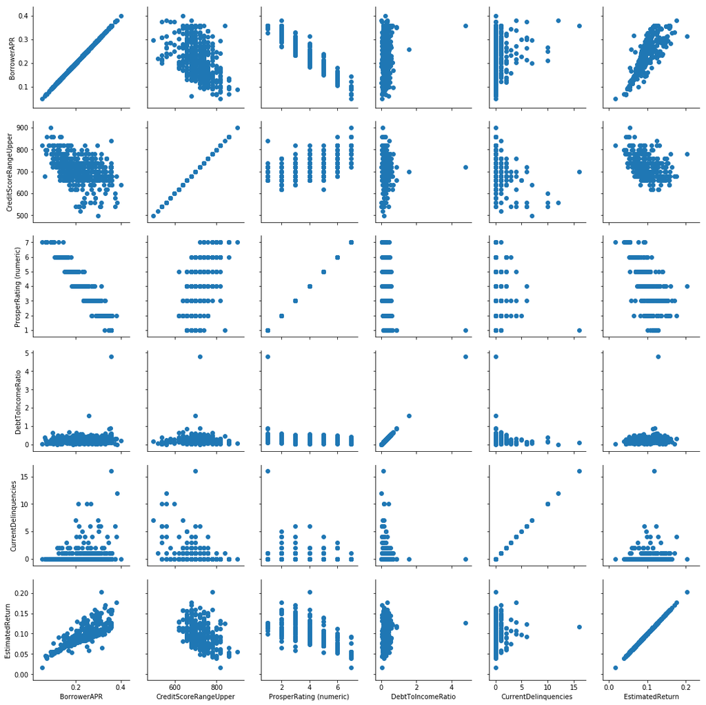

```python
#create pair grid to looks at distribution of numeric columns

samples = np.random.choice(df.shape[0], 500, replace = False)
df_samp = df.loc[samples,:]

g = sb.PairGrid(data = df_samp, vars = numeric_vars )
g = g.map(plt.scatter)
```

After taking a look at the sample distributions above I will look the realtionship between Borrower APR and Current Delinquencies

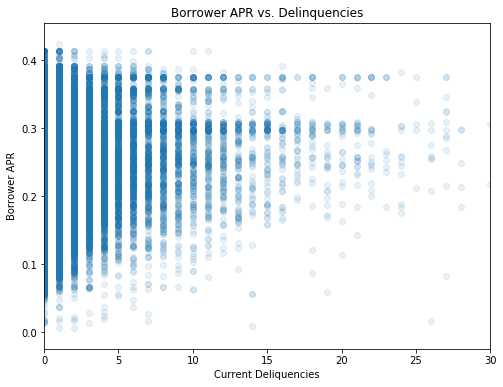

```
                      BorrowerAPR  CurrentDelinquencies
BorrowerAPR              1.000000              0.149404
CurrentDelinquencies     0.149404              1.000000
```

```python
#create scatter plot of deliquencies vs. Borrower APR, print out correlation
plt.figure(figsize = [8, 6])
plt.scatter(data = df_Deliquencies, x = 'CurrentDelinquencies', y = 'BorrowerAPR', alpha = 1/10)
plt.title("Borrower APR vs. Delinquencies")
plt.xlim([0, 30])
plt.xlabel('Current Deliquencies')
plt.ylabel('Borrower APR')
plt.show()



print(df_Deliquencies.corr())
```

theres is a very weak postive correlation between borrower APR and delinquencies. Next I will look into the relationship between borrower APR and Prosper Rating

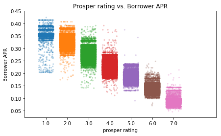

```
                         BorrowerAPR  ProsperRating (numeric)
BorrowerAPR                 1.000000                -0.962151
ProsperRating (numeric)    -0.962151                 1.000000
```

```python
#Create scatter plot of Borrower APR vs. prosper rating, print out correlation

plt.figure(figsize= [7,4])
sb.stripplot(data =  df_ProsperRating,
             x = 'ProsperRating (numeric)', y = 'BorrowerAPR', alpha = 0.3, jitter = .35, size = 3)
plt.xlim([-1, 8])
plt.title("Prosper rating vs. Borrower APR")
plt.xlabel('prosper rating')
plt.ylabel('Borrower APR')
plt.show()
print(df_ProsperRating.corr())
```

There is a very strong negative correlation between Prosper Rating and Borrower APR. Next I will look into the relationship between Estimated Return and Borrower APR.

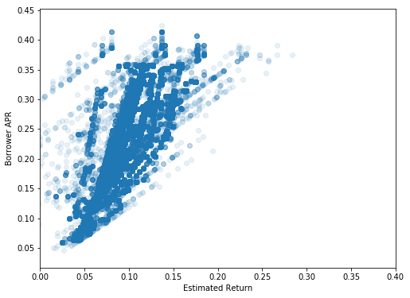

```
                 BorrowerAPR  EstimatedReturn
BorrowerAPR         1.000000         0.794275
EstimatedReturn     0.794275         1.000000
```

```python
#plot estimated return vs. borrower APR
plt.figure(figsize = [8, 6])
plt.scatter(data = df_EstimatedReturn, x = 'EstimatedReturn', y = 'BorrowerAPR', alpha = 1/10)
plt.xlim([0, .4])
plt.xlabel('Estimated Return')
plt.ylabel('Borrower APR')
plt.title("Borrwower APR vs. Estimated Return")
plt.show()

print(df_EstimatedReturn.corr())
```

there is a strong positive correlation between estimated return and borrower APR. Next I will explore the relationship between credit score range upper and borrower APR.

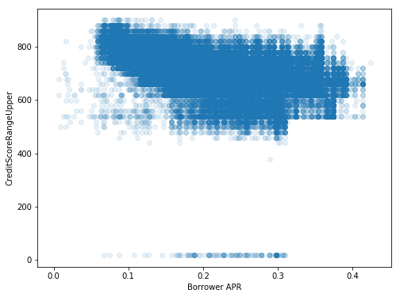

```
                       CreditScoreRangeUpper  BorrowerAPR
CreditScoreRangeUpper               1.000000    -0.429707
BorrowerAPR                        -0.429707     1.000000
```

```python
#plot credit score upper credit score vs. Borrower APR
plt.figure(figsize = [8, 6])
plt.scatter(data = df_Credit, x = 'BorrowerAPR', y = 'CreditScoreRangeUpper', alpha = 1/10)
plt.xlabel('Borrower APR')
plt.ylabel('CreditScoreRangeUpper')
plt.show()

print(df_Credit.corr())
```

### Talk about some of the relationships you observed in this part of the investigation. How did the feature(s) of interest vary with other features in the dataset?

> I looked at the relationship between Borrower APR and current deliqencies, Prosper Rating, Credit Score Range Upper and Estimated return. Borrower APR and Prosper Rating and a very strong negative correlation. Borrower APR and Estimated Return also have strong positive relationship. Borrower Return and Credit Score Range Upper have moderately strong negative correlation

### Did you observe any interesting relationships between the other features (not the main feature(s) of interest)?

> Borrower APR and current deliquencies has a very weak positive correlation.

## Multivariate Exploration

> I will explore the relationships between borrower APR, Credit Score Range Upper, Prosper Rating and estimated return

```
Text(0,0.5,'Borrower APR')
```

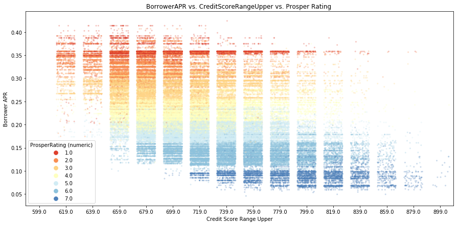

```python
#plot credit score vs. borrower APR vs. Prosper rating

plt.figure(figsize= [15,7])
sb.stripplot(data =  df[df.CreditScoreRangeUpper > 590],
             x = 'CreditScoreRangeUpper', y = 'BorrowerAPR',  hue ='ProsperRating (numeric)',
             palette = "RdYlBu", alpha = 0.3, jitter = .35, size = 3)



plt.title('BorrowerAPR vs. CreditScoreRangeUpper vs. Prosper Rating ')
plt.xlabel('Credit Score Range Upper')
plt.ylabel('Borrower APR')
```

It appears that generally the higher the prosper rating the higher the credit score range upper and the lower the Borrower APR. Next I will look at the relationship between prosper rating, credit score range upper and estimated return.

```
Text(0,0.5,'Estimated Return')
```

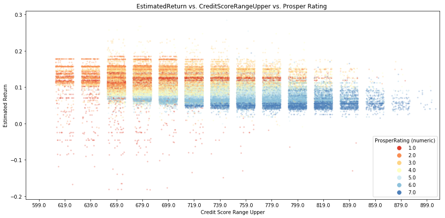

```python
plt.figure(figsize= [15,7])
sb.stripplot(data =  df[df.CreditScoreRangeUpper > 590],
             x = 'CreditScoreRangeUpper', y = 'EstimatedReturn',  hue ='ProsperRating (numeric)',
             palette = "RdYlBu", alpha = 0.3, jitter = .35, size = 3)

plt.title('EstimatedReturn vs. CreditScoreRangeUpper vs. Prosper Rating ')
plt.xlabel('Credit Score Range Upper')
plt.ylabel('Estimated Return')
```

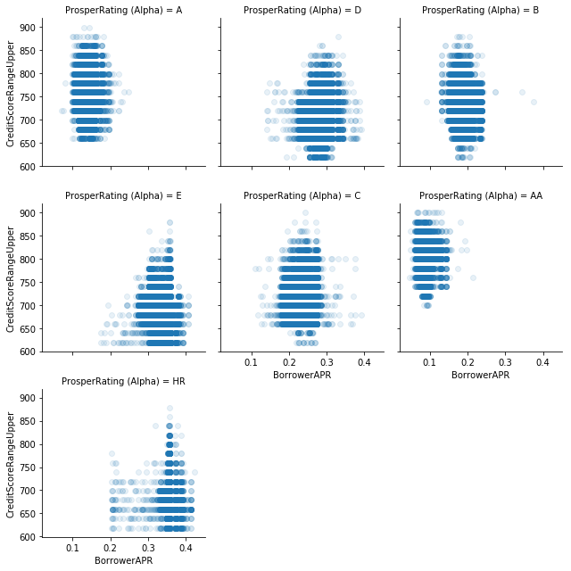

```python
#plot prosper rating vs. borrower apr vs. credit score range upper
g = sb.FacetGrid(data = df, col = 'ProsperRating (Alpha)', col_wrap = 3, size = 3)
g.map(plt.scatter, 'BorrowerAPR', 'CreditScoreRangeUpper', alpha = 0.1)
g.set_xlabels('BorrowerAPR')
g.set_ylabels('CreditScoreRangeUpper')

plt.show()
```

### Talk about some of the relationships you observed in this part of the investigation. Were there features that strengthened each other in terms of looking at your feature(s) of interest?

> It appears that the the higher the credit score, the more likely the loan is to have a high prosper score and a lower Borrower APR. There does not seem to be a very strong relationship between higher credit score and a high return

### Were there any interesting or surprising interactions between features?

> I do find it interesting that a higher credit score does not lead to higher returns. But it does appear to lead to less variability in estimated return.